# Lab 3: Simple Linear Regression

Jiyeong Pyo

17 October 2025

#### Linear Model 1: Variable Selection

#### Answer the following questions

**1. Develop one summary statistics table of the two variables using chatGPT to help (10 points)**

[Chat GPT soluion]

##Load required libraries library(tidyverse) library(moments)

##Example data (replace this with your dataset) data <- tibble( height = rnorm(100, mean = 170, sd = 10), weight = rnorm(100, mean = 70, sd = 15), age = rpois(100, lambda = 35) )

##Define a lookup table for units units <- tibble( variable = c(“height”, “weight”, “age”), units = c(“cm”, “kg”, “years”) )

##Generate summary statistics summary_stats <- data %>% pivot_longer(cols = everything(), names_to = “variable”, values_to = “value”) %>% group_by(variable) %>% summarise( N = sum(!is.na(value)), Mean = mean(value, na.rm = TRUE), Median = median(value, na.rm = TRUE), SD = sd(value, na.rm = TRUE), Skewness = skewness(value, na.rm = TRUE) ) %>% left_join(units, by = “variable”) %>% select(variable, units, N, Mean, Median, SD, Skewness)

##Print the summary table summary_stats

[output not shown]

**2. Make a histogram of each of the variables. The histograms should be professional (Economist ready). (10 points)**

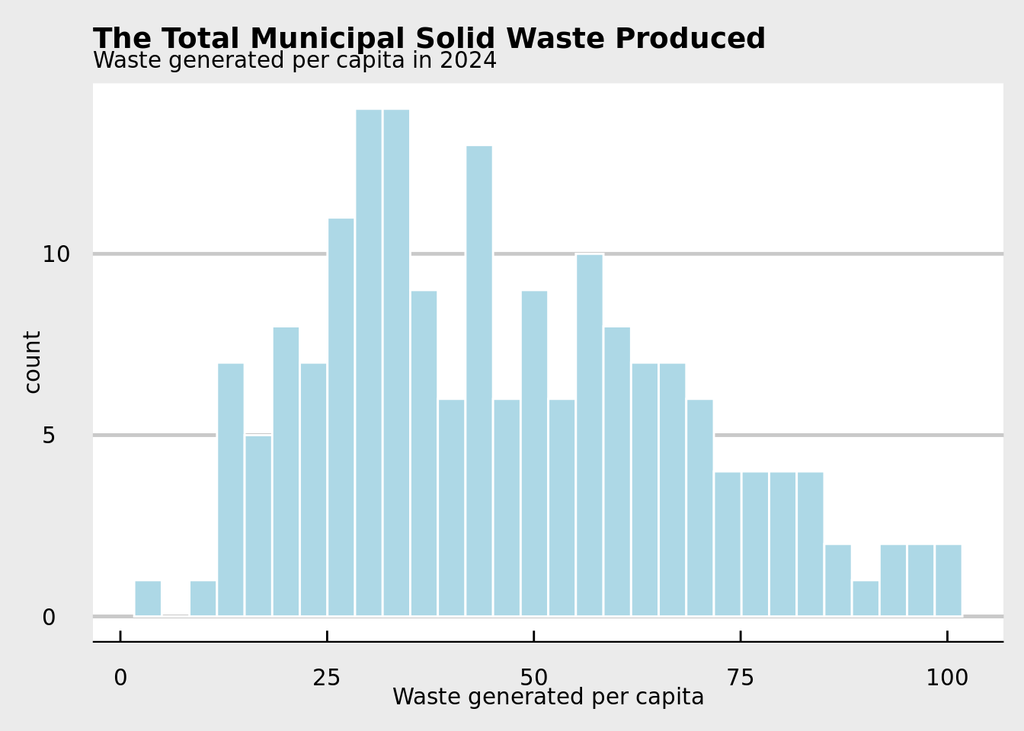

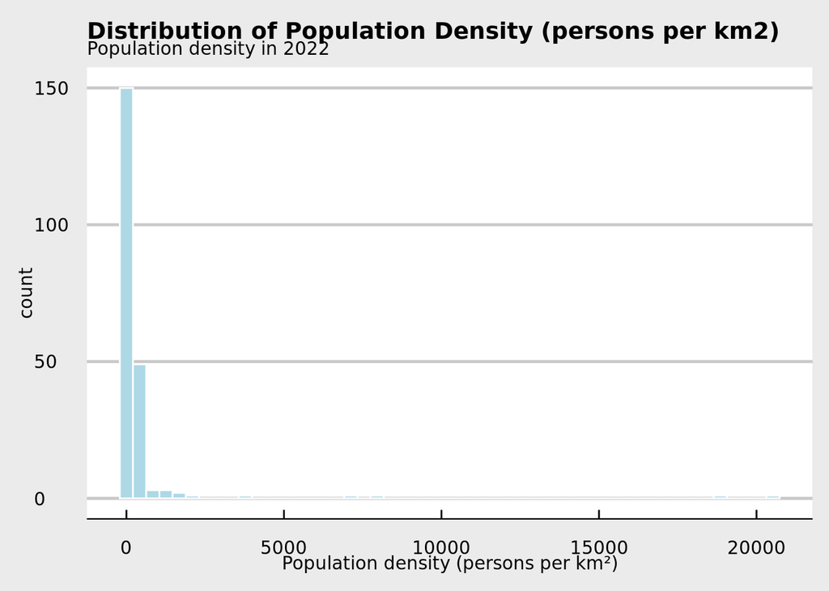

**3. In words, hypothesize a relationship (conceptually) between the two variables (may include directionality). Also include the null and alternative hypothesis for the population slope parameter that are typically used to make inferences in simple linear regression. (10 points)**

-As population density increases, waste generated per capita is expected to increase since higher population concentrations tend to produce more waste.

-Null Hypothesis: There is no linear relationship between population density and waste generated per capita.

-Alternative Hypothesis: There is a linear relationship between population density and waste generated per capita.

**4. Calculate the correlation coefficient between the two variables. Interpret. (10 points)**

```
## [1] -0.07468126
```

**5. Develop and discuss the scatterplots between the two variables. Does the relationship look linear or linear-log (or something else)? Should you transform one or both variables? Include your scatterplots (original, transformed) and discussion in your response. Make sure your scatterplots are appropriately labelled. (10 points)**

[figure not shown]

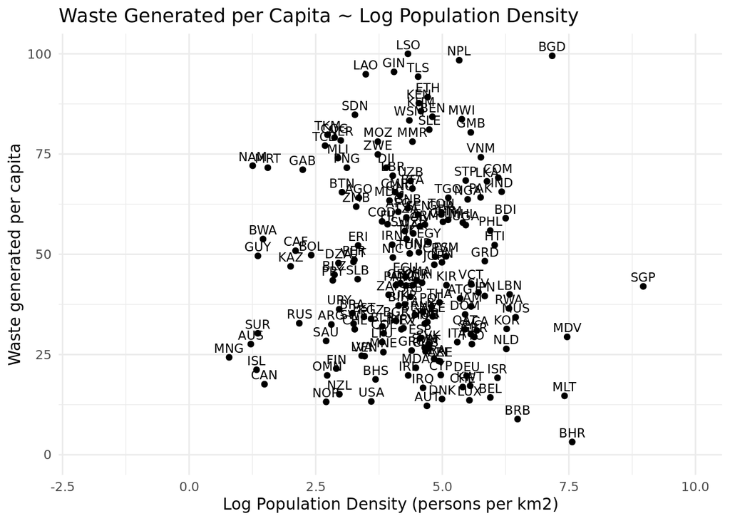

**6. Perform a simple linear regression analysis on the two variables (after transformation, if needed). Make sure that your x and y variables are correct. Write the model equation and interpret the coefficient for the slope, including its significance. (20 points)**

```
##
## Call:
## lm(formula = WPC.new ~ log_pop_den, data = epi_den.df)
##
## Coefficients:
## (Intercept)  log_pop_den
##      51.232       -1.046
```

```
##
## Call:
## lm(formula = WPC.new ~ log_pop_den, data = epi_den.df)
##
## Residuals:
##     Min      1Q  Median      3Q     Max
## -40.122 -16.335  -3.522  14.629  55.765
##
## Coefficients:
##             Estimate Std. Error t value            Pr(>|t|)
## (Intercept)   51.232      5.603   9.143 <0.0000000000000002 ***
## log_pop_den   -1.046      1.227  -0.852               0.395
## ---
## Signif. codes:  0 '***' 0.001 '**' 0.01 '*' 0.05 '.' 0.1 ' ' 1
##
## Residual standard error: 21.86 on 177 degrees of freedom
##   (37 observations deleted due to missingness)
## Multiple R-squared:  0.004084,   Adjusted R-squared:  -0.001543
## F-statistic: 0.7258 on 1 and 177 DF,  p-value: 0.3954
```

**7. Interpret p-value of the slope coefficient in terms of hypothesis in (3) above. (10 points)** The p-value(0.395) showed we fail to reject the null hypothesis that beta 1 equals zero. So it turns out there is no significant linear relatoin between two variables.

**8. Interpret the R-squared value. (10 points)** Multiple R-squared: 0.004084 indicates that the logged population density only explain 0.4% of the Waste generation per capita, suggesting a weak relationship.

**9. Discuss the assumptions of simple linear regression as applied to your final model. Are the underlying assumptions of simple linear regression met? (10 points)**

**Please make sure your knitted html is clean of coding, warnings, and messages.** **Uploaded your knitted html and Rmd to Assignments with LastName_First.html; LastName_First.Rmd**